# Optimal Treatment Analysis

## Outcome Variable

**Outcome Variable:** ever_stunted

## Predictor Variables

**Intervention Variable:** mage

**Adjustment Set:**

- arm
- meducyrs
- feducyrs
- W_mhtcm
- single
- delta_meducyrs
- delta_feducyrs
- delta_W_mhtcm
- delta_single

## Stratifying Variables

The analysis was stratified on these variable(s):

- agecat
- studyid
- country

## Data Summary

| agecat | studyid | country | mage | ever_stunted | n_cell | n |
| --- | --- | --- | --- | --- | --- | --- |
| 0-24 months | ki0047075b-MAL-ED | BANGLADESH | [20-30) | 0 | 78 | 265 |
| 0-24 months | ki0047075b-MAL-ED | BANGLADESH | [20-30) | 1 | 104 | 265 |
| 0-24 months | ki0047075b-MAL-ED | BANGLADESH | <20 | 0 | 8 | 265 |
| 0-24 months | ki0047075b-MAL-ED | BANGLADESH | <20 | 1 | 29 | 265 |
| 0-24 months | ki0047075b-MAL-ED | BANGLADESH | >=30 | 0 | 18 | 265 |
| 0-24 months | ki0047075b-MAL-ED | BANGLADESH | >=30 | 1 | 28 | 265 |
| 0-24 months | ki0047075b-MAL-ED | BRAZIL | [20-30) | 0 | 103 | 233 |
| 0-24 months | ki0047075b-MAL-ED | BRAZIL | [20-30) | 1 | 36 | 233 |
| 0-24 months | ki0047075b-MAL-ED | BRAZIL | <20 | 0 | 34 | 233 |
| 0-24 months | ki0047075b-MAL-ED | BRAZIL | <20 | 1 | 9 | 233 |
| 0-24 months | ki0047075b-MAL-ED | BRAZIL | >=30 | 0 | 42 | 233 |
| 0-24 months | ki0047075b-MAL-ED | BRAZIL | >=30 | 1 | 9 | 233 |
| 0-24 months | ki0047075b-MAL-ED | INDIA | [20-30) | 0 | 75 | 249 |
| 0-24 months | ki0047075b-MAL-ED | INDIA | [20-30) | 1 | 119 | 249 |
| 0-24 months | ki0047075b-MAL-ED | INDIA | <20 | 0 | 15 | 249 |
| 0-24 months | ki0047075b-MAL-ED | INDIA | <20 | 1 | 19 | 249 |
| 0-24 months | ki0047075b-MAL-ED | INDIA | >=30 | 0 | 11 | 249 |
| 0-24 months | ki0047075b-MAL-ED | INDIA | >=30 | 1 | 10 | 249 |
| 0-24 months | ki0047075b-MAL-ED | NEPAL | [20-30) | 0 | 127 | 240 |
| 0-24 months | ki0047075b-MAL-ED | NEPAL | [20-30) | 1 | 62 | 240 |
| 0-24 months | ki0047075b-MAL-ED | NEPAL | <20 | 0 | 2 | 240 |
| 0-24 months | ki0047075b-MAL-ED | NEPAL | <20 | 1 | 3 | 240 |
| 0-24 months | ki0047075b-MAL-ED | NEPAL | >=30 | 0 | 28 | 240 |
| 0-24 months | ki0047075b-MAL-ED | NEPAL | >=30 | 1 | 18 | 240 |
| 0-24 months | ki0047075b-MAL-ED | PERU | [20-30) | 0 | 61 | 303 |
| 0-24 months | ki0047075b-MAL-ED | PERU | [20-30) | 1 | 92 | 303 |
| 0-24 months | ki0047075b-MAL-ED | PERU | <20 | 0 | 29 | 303 |
| 0-24 months | ki0047075b-MAL-ED | PERU | <20 | 1 | 54 | 303 |
| 0-24 months | ki0047075b-MAL-ED | PERU | >=30 | 0 | 25 | 303 |
| 0-24 months | ki0047075b-MAL-ED | PERU | >=30 | 1 | 42 | 303 |

[output cut: 450 more lines]

The following strata were considered:

- agecat: 0-24 months, studyid: ki0047075b-MAL-ED, country: BANGLADESH
- agecat: 0-24 months, studyid: ki0047075b-MAL-ED, country: BRAZIL
- agecat: 0-24 months, studyid: ki0047075b-MAL-ED, country: INDIA
- agecat: 0-24 months, studyid: ki0047075b-MAL-ED, country: NEPAL
- agecat: 0-24 months, studyid: ki0047075b-MAL-ED, country: PERU
- agecat: 0-24 months, studyid: ki0047075b-MAL-ED, country: SOUTH AFRICA
- agecat: 0-24 months, studyid: ki0047075b-MAL-ED, country: TANZANIA, UNITED REPUBLIC OF
- agecat: 0-24 months, studyid: ki1000108-CMC-V-BCS-2002, country: INDIA
- agecat: 0-24 months, studyid: ki1000108-IRC, country: INDIA
- agecat: 0-24 months, studyid: ki1000109-EE, country: PAKISTAN
- agecat: 0-24 months, studyid: ki1000304b-SAS-CompFeed, country: INDIA
- agecat: 0-24 months, studyid: ki1000304b-SAS-FoodSuppl, country: INDIA
- agecat: 0-24 months, studyid: ki1017093-NIH-Birth, country: BANGLADESH
- agecat: 0-24 months, studyid: ki1017093b-PROVIDE, country: BANGLADESH
- agecat: 0-24 months, studyid: ki1017093c-NIH-Crypto, country: BANGLADESH
- agecat: 0-24 months, studyid: ki1066203-TanzaniaChild2, country: TANZANIA, UNITED REPUBLIC OF
- agecat: 0-24 months, studyid: ki1101329-Keneba, country: GAMBIA
- agecat: 0-24 months, studyid: ki1112895-Guatemala BSC, country: GUATEMALA
- agecat: 0-24 months, studyid: ki1112895-iLiNS-Zinc, country: BURKINA FASO
- agecat: 0-24 months, studyid: ki1113344-GMS-Nepal, country: NEPAL
- agecat: 0-24 months, studyid: ki1119695-PROBIT, country: BELARUS
- agecat: 0-24 months, studyid: ki1126311-ZVITAMBO, country: ZIMBABWE
- agecat: 0-24 months, studyid: ki1135781-COHORTS, country: GUATEMALA
- agecat: 0-24 months, studyid: ki1135781-COHORTS, country: INDIA
- agecat: 0-24 months, studyid: ki1135781-COHORTS, country: PHILIPPINES
- agecat: 0-24 months, studyid: ki1148112-LCNI-5, country: MALAWI
- agecat: 0-24 months, studyid: kiGH5241-JiVitA-3, country: BANGLADESH
- agecat: 0-6 months, studyid: ki0047075b-MAL-ED, country: BANGLADESH
- agecat: 0-6 months, studyid: ki0047075b-MAL-ED, country: BRAZIL
- agecat: 0-6 months, studyid: ki0047075b-MAL-ED, country: INDIA
- agecat: 0-6 months, studyid: ki0047075b-MAL-ED, country: NEPAL
- agecat: 0-6 months, studyid: ki0047075b-MAL-ED, country: PERU
- agecat: 0-6 months, studyid: ki0047075b-MAL-ED, country: SOUTH AFRICA
- agecat: 0-6 months, studyid: ki0047075b-MAL-ED, country: TANZANIA, UNITED REPUBLIC OF
- agecat: 0-6 months, studyid: ki1000108-CMC-V-BCS-2002, country: INDIA
- agecat: 0-6 months, studyid: ki1000108-IRC, country: INDIA
- agecat: 0-6 months, studyid: ki1000109-EE, country: PAKISTAN
- agecat: 0-6 months, studyid: ki1000304b-SAS-CompFeed, country: INDIA
- agecat: 0-6 months, studyid: ki1000304b-SAS-FoodSuppl, country: INDIA
- agecat: 0-6 months, studyid: ki1017093-NIH-Birth, country: BANGLADESH
- agecat: 0-6 months, studyid: ki1017093b-PROVIDE, country: BANGLADESH
- agecat: 0-6 months, studyid: ki1017093c-NIH-Crypto, country: BANGLADESH
- agecat: 0-6 months, studyid: ki1066203-TanzaniaChild2, country: TANZANIA, UNITED REPUBLIC OF
- agecat: 0-6 months, studyid: ki1101329-Keneba, country: GAMBIA
- agecat: 0-6 months, studyid: ki1112895-Guatemala BSC, country: GUATEMALA
- agecat: 0-6 months, studyid: ki1113344-GMS-Nepal, country: NEPAL
- agecat: 0-6 months, studyid: ki1119695-PROBIT, country: BELARUS
- agecat: 0-6 months, studyid: ki1126311-ZVITAMBO, country: ZIMBABWE
- agecat: 0-6 months, studyid: ki1135781-COHORTS, country: GUATEMALA
- agecat: 0-6 months, studyid: ki1135781-COHORTS, country: INDIA
- agecat: 0-6 months, studyid: ki1135781-COHORTS, country: PHILIPPINES
- agecat: 0-6 months, studyid: ki1148112-LCNI-5, country: MALAWI
- agecat: 0-6 months, studyid: kiGH5241-JiVitA-3, country: BANGLADESH
- agecat: 6-24 months, studyid: ki0047075b-MAL-ED, country: BANGLADESH
- agecat: 6-24 months, studyid: ki0047075b-MAL-ED, country: BRAZIL
- agecat: 6-24 months, studyid: ki0047075b-MAL-ED, country: INDIA
- agecat: 6-24 months, studyid: ki0047075b-MAL-ED, country: NEPAL
- agecat: 6-24 months, studyid: ki0047075b-MAL-ED, country: PERU
- agecat: 6-24 months, studyid: ki0047075b-MAL-ED, country: SOUTH AFRICA
- agecat: 6-24 months, studyid: ki0047075b-MAL-ED, country: TANZANIA, UNITED REPUBLIC OF
- agecat: 6-24 months, studyid: ki1000108-CMC-V-BCS-2002, country: INDIA
- agecat: 6-24 months, studyid: ki1000108-IRC, country: INDIA
- agecat: 6-24 months, studyid: ki1000109-EE, country: PAKISTAN
- agecat: 6-24 months, studyid: ki1000304b-SAS-CompFeed, country: INDIA
- agecat: 6-24 months, studyid: ki1000304b-SAS-FoodSuppl, country: INDIA
- agecat: 6-24 months, studyid: ki1017093-NIH-Birth, country: BANGLADESH
- agecat: 6-24 months, studyid: ki1017093b-PROVIDE, country: BANGLADESH
- agecat: 6-24 months, studyid: ki1017093c-NIH-Crypto, country: BANGLADESH
- agecat: 6-24 months, studyid: ki1066203-TanzaniaChild2, country: TANZANIA, UNITED REPUBLIC OF
- agecat: 6-24 months, studyid: ki1101329-Keneba, country: GAMBIA
- agecat: 6-24 months, studyid: ki1112895-Guatemala BSC, country: GUATEMALA
- agecat: 6-24 months, studyid: ki1112895-iLiNS-Zinc, country: BURKINA FASO
- agecat: 6-24 months, studyid: ki1113344-GMS-Nepal, country: NEPAL
- agecat: 6-24 months, studyid: ki1119695-PROBIT, country: BELARUS
- agecat: 6-24 months, studyid: ki1126311-ZVITAMBO, country: ZIMBABWE
- agecat: 6-24 months, studyid: ki1135781-COHORTS, country: GUATEMALA
- agecat: 6-24 months, studyid: ki1135781-COHORTS, country: INDIA
- agecat: 6-24 months, studyid: ki1135781-COHORTS, country: PHILIPPINES
- agecat: 6-24 months, studyid: ki1148112-LCNI-5, country: MALAWI
- agecat: 6-24 months, studyid: kiGH5241-JiVitA-3, country: BANGLADESH

### Dropped Strata

Some strata were dropped due to rare outcomes:

- agecat: 0-24 months, studyid: ki0047075b-MAL-ED, country: NEPAL
- agecat: 0-24 months, studyid: ki0047075b-MAL-ED, country: TANZANIA, UNITED REPUBLIC OF
- agecat: 0-24 months, studyid: ki1000108-CMC-V-BCS-2002, country: INDIA
- agecat: 0-24 months, studyid: ki1000109-EE, country: PAKISTAN
- agecat: 0-6 months, studyid: ki0047075b-MAL-ED, country: INDIA
- agecat: 0-6 months, studyid: ki0047075b-MAL-ED, country: NEPAL
- agecat: 0-6 months, studyid: ki0047075b-MAL-ED, country: TANZANIA, UNITED REPUBLIC OF
- agecat: 0-6 months, studyid: ki1000109-EE, country: PAKISTAN
- agecat: 6-24 months, studyid: ki0047075b-MAL-ED, country: BRAZIL
- agecat: 6-24 months, studyid: ki0047075b-MAL-ED, country: NEPAL
- agecat: 6-24 months, studyid: ki0047075b-MAL-ED, country: TANZANIA, UNITED REPUBLIC OF
- agecat: 6-24 months, studyid: ki1000108-CMC-V-BCS-2002, country: INDIA
- agecat: 6-24 months, studyid: ki1000108-IRC, country: INDIA
- agecat: 6-24 months, studyid: ki1000109-EE, country: PAKISTAN

## Methods Detail

We’re interested in the causal parameters $E[Y_a]$ for all values of $a \in \mathcal{A}$. These parameters represent the mean outcome if, possibly contrary to fact, we intervened to set all units to have $A=a$. Under the randomization and positivity assumptions, these are identified by the statistical parameters $\psi_a=E_W[E_{Y|A,W}(Y|A=a,W)]$. In addition, we’re interested in the mean of $Y$, $E[Y]$ under no intervention (the observed mean). We will estimate these parameters by using SuperLearner to fit the relevant likelihood factors – $E_{Y|A,W}(Y|A=a,W)$ and $p(A=a|W)$, and then updating our likelihood fit using a joint TMLE.

For unadjusted analyses ($W=\{\}$), initial likelihoods were estimated using Lrnr_glm to estimate the simple $E(Y|A)$ and Lrnr_mean to estimate $p(A)$. For adjusted analyses, a small library containing Lrnr_glmnet, Lrnr_xgboost, and Lrnr_mean was used.

Having estimated these parameters, we will then use the delta method to estimate relative risks and attributable risks relative to a prespecified baseline level of $A$.

# Results Detail

## Results Plots

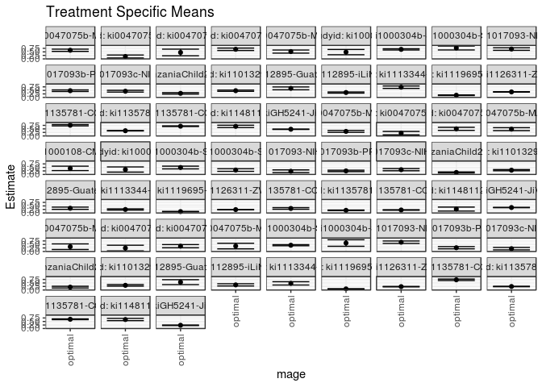

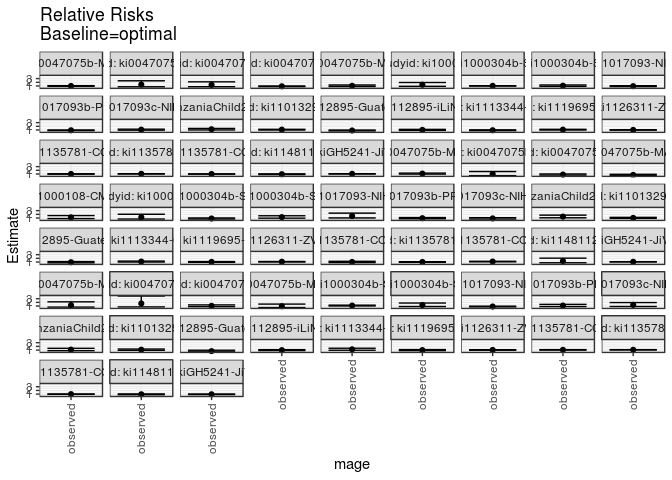

## Results Table

### Parameter: TSM

| agecat | studyid | country | intervention_level | baseline_level | estimate | ci_lower | ci_upper |
| --- | --- | --- | --- | --- | --- | --- | --- |
| 0-24 months | ki0047075b-MAL-ED | BANGLADESH | optimal | NA | 0.6143990 | 0.5346152 | 0.6941829 |
| 0-24 months | ki0047075b-MAL-ED | BRAZIL | optimal | NA | 0.1697115 | 0.0639437 | 0.2754793 |
| 0-24 months | ki0047075b-MAL-ED | INDIA | optimal | NA | 0.4584377 | 0.2230346 | 0.6938408 |
| 0-24 months | ki0047075b-MAL-ED | PERU | optimal | NA | 0.6855462 | 0.5999010 | 0.7711914 |
| 0-24 months | ki0047075b-MAL-ED | SOUTH AFRICA | optimal | NA | 0.5215143 | 0.4102951 | 0.6327335 |
| 0-24 months | ki1000108-IRC | INDIA | optimal | NA | 0.4825818 | 0.2947386 | 0.6704250 |
| 0-24 months | ki1000304b-SAS-CompFeed | INDIA | optimal | NA | 0.6765972 | 0.6329778 | 0.7202165 |
| 0-24 months | ki1000304b-SAS-FoodSuppl | INDIA | optimal | NA | 0.7765818 | 0.6364826 | 0.9166809 |
| 0-24 months | ki1017093-NIH-Birth | BANGLADESH | optimal | NA | 0.7015100 | 0.6109028 | 0.7921172 |
| 0-24 months | ki1017093b-PROVIDE | BANGLADESH | optimal | NA | 0.4768244 | 0.4206889 | 0.5329599 |
| 0-24 months | ki1017093c-NIH-Crypto | BANGLADESH | optimal | NA | 0.4418985 | 0.3775137 | 0.5062833 |
| 0-24 months | ki1066203-TanzaniaChild2 | TANZANIA, UNITED REPUBLIC OF | optimal | NA | 0.2899124 | 0.2379881 | 0.3418368 |
| 0-24 months | ki1101329-Keneba | GAMBIA | optimal | NA | 0.4777526 | 0.4333292 | 0.5221759 |
| 0-24 months | ki1112895-Guatemala BSC | GUATEMALA | optimal | NA | 0.6439910 | 0.5433398 | 0.7446422 |
| 0-24 months | ki1112895-iLiNS-Zinc | BURKINA FASO | optimal | NA | 0.3480329 | 0.3071285 | 0.3889372 |
| 0-24 months | ki1113344-GMS-Nepal | NEPAL | optimal | NA | 0.7271957 | 0.6402045 | 0.8141868 |
| 0-24 months | ki1119695-PROBIT | BELARUS | optimal | NA | 0.1543303 | 0.1324573 | 0.1762034 |
| 0-24 months | ki1126311-ZVITAMBO | ZIMBABWE | optimal | NA | 0.3913810 | 0.3754093 | 0.4073528 |
| 0-24 months | ki1135781-COHORTS | GUATEMALA | optimal | NA | 0.7597025 | 0.7160366 | 0.8033684 |
| 0-24 months | ki1135781-COHORTS | INDIA | optimal | NA | 0.3708686 | 0.3541752 | 0.3875620 |
| 0-24 months | ki1135781-COHORTS | PHILIPPINES | optimal | NA | 0.6911045 | 0.6653345 | 0.7168745 |
| 0-24 months | ki1148112-LCNI-5 | MALAWI | optimal | NA | 0.6793891 | 0.5966517 | 0.7621264 |
| 0-24 months | kiGH5241-JiVitA-3 | BANGLADESH | optimal | NA | 0.4749413 | 0.4618651 | 0.4880175 |
| 0-6 months | ki0047075b-MAL-ED | BANGLADESH | optimal | NA | 0.3225379 | 0.2545555 | 0.3905204 |
| 0-6 months | ki0047075b-MAL-ED | BRAZIL | optimal | NA | 0.1992114 | 0.0781281 | 0.3202947 |
| 0-6 months | ki0047075b-MAL-ED | PERU | optimal | NA | 0.5046957 | 0.3943463 | 0.6150451 |
| 0-6 months | ki0047075b-MAL-ED | SOUTH AFRICA | optimal | NA | 0.4821118 | 0.3783158 | 0.5859078 |
| 0-6 months | ki1000108-CMC-V-BCS-2002 | INDIA | optimal | NA | 0.4316618 | 0.2760244 | 0.5872992 |
| 0-6 months | ki1000108-IRC | INDIA | optimal | NA | 0.3500590 | 0.1661066 | 0.5340115 |
| 0-6 months | ki1000304b-SAS-CompFeed | INDIA | optimal | NA | 0.4929324 | 0.3957431 | 0.5901216 |
| 0-6 months | ki1000304b-SAS-FoodSuppl | INDIA | optimal | NA | 0.3132627 | 0.2215716 | 0.4049538 |
| 0-6 months | ki1017093-NIH-Birth | BANGLADESH | optimal | NA | 0.2254138 | 0.1283796 | 0.3224480 |
| 0-6 months | ki1017093b-PROVIDE | BANGLADESH | optimal | NA | 0.2515811 | 0.2004040 | 0.3027581 |
| 0-6 months | ki1017093c-NIH-Crypto | BANGLADESH | optimal | NA | 0.3381244 | 0.2617319 | 0.4145169 |
| 0-6 months | ki1066203-TanzaniaChild2 | TANZANIA, UNITED REPUBLIC OF | optimal | NA | 0.1413701 | 0.1027622 | 0.1799780 |
| 0-6 months | ki1101329-Keneba | GAMBIA | optimal | NA | 0.3033772 | 0.2593265 | 0.3474278 |
| 0-6 months | ki1112895-Guatemala BSC | GUATEMALA | optimal | NA | 0.3351244 | 0.2556772 | 0.4145715 |
| 0-6 months | ki1113344-GMS-Nepal | NEPAL | optimal | NA | 0.2475917 | 0.2045535 | 0.2906299 |
| 0-6 months | ki1119695-PROBIT | BELARUS | optimal | NA | 0.0968390 | 0.0798145 | 0.1138634 |
| 0-6 months | ki1126311-ZVITAMBO | ZIMBABWE | optimal | NA | 0.2385747 | 0.2235141 | 0.2536352 |
| 0-6 months | ki1135781-COHORTS | GUATEMALA | optimal | NA | 0.3197674 | 0.2612044 | 0.3783305 |
| 0-6 months | ki1135781-COHORTS | INDIA | optimal | NA | 0.1883186 | 0.1702741 | 0.2063631 |
| 0-6 months | ki1135781-COHORTS | PHILIPPINES | optimal | NA | 0.2115896 | 0.1920865 | 0.2310928 |
| 0-6 months | ki1148112-LCNI-5 | MALAWI | optimal | NA | 0.2765522 | 0.1360739 | 0.4170306 |
| 0-6 months | kiGH5241-JiVitA-3 | BANGLADESH | optimal | NA | 0.3865646 | 0.3738675 | 0.3992618 |
| 6-24 months | ki0047075b-MAL-ED | BANGLADESH | optimal | NA | 0.3392426 | 0.1393706 | 0.5391146 |
| 6-24 months | ki0047075b-MAL-ED | INDIA | optimal | NA | 0.2430719 | 0.0424372 | 0.4437066 |
| 6-24 months | ki0047075b-MAL-ED | PERU | optimal | NA | 0.3758443 | 0.2625273 | 0.4891613 |
| 6-24 months | ki0047075b-MAL-ED | SOUTH AFRICA | optimal | NA | 0.3850268 | 0.1855304 | 0.5845232 |
| 6-24 months | ki1000304b-SAS-CompFeed | INDIA | optimal | NA | 0.4447805 | 0.4044336 | 0.4851273 |
| 6-24 months | ki1000304b-SAS-FoodSuppl | INDIA | optimal | NA | 0.6013912 | 0.3689391 | 0.8338433 |
| 6-24 months | ki1017093-NIH-Birth | BANGLADESH | optimal | NA | 0.6585963 | 0.5723884 | 0.7448042 |
| 6-24 months | ki1017093b-PROVIDE | BANGLADESH | optimal | NA | 0.2676360 | 0.1878919 | 0.3473801 |
| 6-24 months | ki1017093c-NIH-Crypto | BANGLADESH | optimal | NA | 0.2005686 | 0.1140507 | 0.2870865 |
| 6-24 months | ki1066203-TanzaniaChild2 | TANZANIA, UNITED REPUBLIC OF | optimal | NA | 0.2030225 | 0.1421787 | 0.2638663 |
| 6-24 months | ki1101329-Keneba | GAMBIA | optimal | NA | 0.3316947 | 0.2751969 | 0.3881925 |
| 6-24 months | ki1112895-Guatemala BSC | GUATEMALA | optimal | NA | 0.5560593 | 0.3806526 | 0.7314659 |
| 6-24 months | ki1112895-iLiNS-Zinc | BURKINA FASO | optimal | NA | 0.3634309 | 0.2849461 | 0.4419157 |
| 6-24 months | ki1113344-GMS-Nepal | NEPAL | optimal | NA | 0.4700015 | 0.3541371 | 0.5858659 |
| 6-24 months | ki1119695-PROBIT | BELARUS | optimal | NA | 0.0776280 | 0.0661761 | 0.0890799 |
| 6-24 months | ki1126311-ZVITAMBO | ZIMBABWE | optimal | NA | 0.2379540 | 0.2202170 | 0.2556910 |
| 6-24 months | ki1135781-COHORTS | GUATEMALA | optimal | NA | 0.7237199 | 0.6716389 | 0.7758009 |
| 6-24 months | ki1135781-COHORTS | INDIA | optimal | NA | 0.2483353 | 0.2322396 | 0.2644309 |
| 6-24 months | ki1135781-COHORTS | PHILIPPINES | optimal | NA | 0.6556264 | 0.6269436 | 0.6843092 |
| 6-24 months | ki1148112-LCNI-5 | MALAWI | optimal | NA | 0.6392417 | 0.5594539 | 0.7190295 |
| 6-24 months | kiGH5241-JiVitA-3 | BANGLADESH | optimal | NA | 0.2304729 | 0.2121124 | 0.2488335 |

### Parameter: E(Y)

| agecat | studyid | country | intervention_level | baseline_level | estimate | ci_lower | ci_upper |
| --- | --- | --- | --- | --- | --- | --- | --- |
| 0-24 months | ki0047075b-MAL-ED | BANGLADESH | observed | NA | 0.6075472 | 0.5486452 | 0.6664491 |
| 0-24 months | ki0047075b-MAL-ED | BRAZIL | observed | NA | 0.2317597 | 0.1774632 | 0.2860561 |
| 0-24 months | ki0047075b-MAL-ED | INDIA | observed | NA | 0.5943775 | 0.5332672 | 0.6554878 |
| 0-24 months | ki0047075b-MAL-ED | PERU | observed | NA | 0.6204620 | 0.5657315 | 0.6751926 |
| 0-24 months | ki0047075b-MAL-ED | SOUTH AFRICA | observed | NA | 0.5445860 | 0.4894148 | 0.5997572 |
| 0-24 months | ki1000108-IRC | INDIA | observed | NA | 0.6414634 | 0.5949863 | 0.6879405 |
| 0-24 months | ki1000304b-SAS-CompFeed | INDIA | observed | NA | 0.6914547 | 0.6510509 | 0.7318584 |
| 0-24 months | ki1000304b-SAS-FoodSuppl | INDIA | observed | NA | 0.8277512 | 0.7915095 | 0.8639929 |
| 0-24 months | ki1017093-NIH-Birth | BANGLADESH | observed | NA | 0.6634769 | 0.6264616 | 0.7004922 |
| 0-24 months | ki1017093b-PROVIDE | BANGLADESH | observed | NA | 0.4342857 | 0.3975409 | 0.4710305 |
| 0-24 months | ki1017093c-NIH-Crypto | BANGLADESH | observed | NA | 0.4775726 | 0.4419904 | 0.5131548 |
| 0-24 months | ki1066203-TanzaniaChild2 | TANZANIA, UNITED REPUBLIC OF | observed | NA | 0.3459596 | 0.3268289 | 0.3650903 |
| 0-24 months | ki1101329-Keneba | GAMBIA | observed | NA | 0.5183631 | 0.5000444 | 0.5366817 |
| 0-24 months | ki1112895-Guatemala BSC | GUATEMALA | observed | NA | 0.5551601 | 0.4969525 | 0.6133678 |
| 0-24 months | ki1112895-iLiNS-Zinc | BURKINA FASO | observed | NA | 0.3559962 | 0.3060347 | 0.4059578 |
| 0-24 months | ki1113344-GMS-Nepal | NEPAL | observed | NA | 0.6744186 | 0.6369554 | 0.7118819 |
| 0-24 months | ki1119695-PROBIT | BELARUS | observed | NA | 0.1674854 | 0.1488048 | 0.1861659 |
| 0-24 months | ki1126311-ZVITAMBO | ZIMBABWE | observed | NA | 0.3966365 | 0.3885423 | 0.4047307 |
| 0-24 months | ki1135781-COHORTS | GUATEMALA | observed | NA | 0.7639706 | 0.7413939 | 0.7865473 |
| 0-24 months | ki1135781-COHORTS | INDIA | observed | NA | 0.3877282 | 0.3746257 | 0.4008307 |
| 0-24 months | ki1135781-COHORTS | PHILIPPINES | observed | NA | 0.6863963 | 0.6699497 | 0.7028430 |
| 0-24 months | ki1148112-LCNI-5 | MALAWI | observed | NA | 0.6373134 | 0.6008819 | 0.6737450 |
| 0-24 months | kiGH5241-JiVitA-3 | BANGLADESH | observed | NA | 0.4937741 | 0.4859396 | 0.5016087 |
| 0-6 months | ki0047075b-MAL-ED | BANGLADESH | observed | NA | 0.3547170 | 0.2970055 | 0.4124285 |
| 0-6 months | ki0047075b-MAL-ED | BRAZIL | observed | NA | 0.1931330 | 0.1423366 | 0.2439295 |
| 0-6 months | ki0047075b-MAL-ED | PERU | observed | NA | 0.4257426 | 0.3699763 | 0.4815088 |
| 0-6 months | ki0047075b-MAL-ED | SOUTH AFRICA | observed | NA | 0.3598726 | 0.3067005 | 0.4130447 |
| 0-6 months | ki1000108-CMC-V-BCS-2002 | INDIA | observed | NA | 0.5108696 | 0.4597270 | 0.5620121 |
| 0-6 months | ki1000108-IRC | INDIA | observed | NA | 0.4243902 | 0.3764905 | 0.4722900 |
| 0-6 months | ki1000304b-SAS-CompFeed | INDIA | observed | NA | 0.4254902 | 0.3977202 | 0.4532601 |
| 0-6 months | ki1000304b-SAS-FoodSuppl | INDIA | observed | NA | 0.3894231 | 0.3425088 | 0.4363374 |
| 0-6 months | ki1017093-NIH-Birth | BANGLADESH | observed | NA | 0.3476874 | 0.3103810 | 0.3849938 |
| 0-6 months | ki1017093b-PROVIDE | BANGLADESH | observed | NA | 0.2385714 | 0.2069753 | 0.2701675 |
| 0-6 months | ki1017093c-NIH-Crypto | BANGLADESH | observed | NA | 0.3021108 | 0.2694011 | 0.3348205 |
| 0-6 months | ki1066203-TanzaniaChild2 | TANZANIA, UNITED REPUBLIC OF | observed | NA | 0.1944444 | 0.1785274 | 0.2103615 |
| 0-6 months | ki1101329-Keneba | GAMBIA | observed | NA | 0.3127302 | 0.2943427 | 0.3311178 |
| 0-6 months | ki1112895-Guatemala BSC | GUATEMALA | observed | NA | 0.3181818 | 0.2618904 | 0.3744732 |
| 0-6 months | ki1113344-GMS-Nepal | NEPAL | observed | NA | 0.2774086 | 0.2416141 | 0.3132032 |
| 0-6 months | ki1119695-PROBIT | BELARUS | observed | NA | 0.0995087 | 0.0864641 | 0.1125533 |
| 0-6 months | ki1126311-ZVITAMBO | ZIMBABWE | observed | NA | 0.2580829 | 0.2508371 | 0.2653287 |
| 0-6 months | ki1135781-COHORTS | GUATEMALA | observed | NA | 0.3253896 | 0.2975756 | 0.3532035 |
| 0-6 months | ki1135781-COHORTS | INDIA | observed | NA | 0.1902629 | 0.1795262 | 0.2009996 |
| 0-6 months | ki1135781-COHORTS | PHILIPPINES | observed | NA | 0.2390451 | 0.2239262 | 0.2541640 |
| 0-6 months | ki1148112-LCNI-5 | MALAWI | observed | NA | 0.3545455 | 0.2911884 | 0.4179025 |
| 0-6 months | kiGH5241-JiVitA-3 | BANGLADESH | observed | NA | 0.4107662 | 0.4033277 | 0.4182048 |
| 6-24 months | ki0047075b-MAL-ED | BANGLADESH | observed | NA | 0.4213836 | 0.3443902 | 0.4983771 |
| 6-24 months | ki0047075b-MAL-ED | INDIA | observed | NA | 0.4129032 | 0.3351414 | 0.4906651 |
| 6-24 months | ki0047075b-MAL-ED | PERU | observed | NA | 0.3959732 | 0.3171819 | 0.4747644 |
| 6-24 months | ki0047075b-MAL-ED | SOUTH AFRICA | observed | NA | 0.3647799 | 0.2897219 | 0.4398379 |
| 6-24 months | ki1000304b-SAS-CompFeed | INDIA | observed | NA | 0.5030750 | 0.4588491 | 0.5473009 |
| 6-24 months | ki1000304b-SAS-FoodSuppl | INDIA | observed | NA | 0.7572016 | 0.7031798 | 0.8112234 |
| 6-24 months | ki1017093-NIH-Birth | BANGLADESH | observed | NA | 0.5739130 | 0.5216565 | 0.6261696 |
| 6-24 months | ki1017093b-PROVIDE | BANGLADESH | observed | NA | 0.2997812 | 0.2577294 | 0.3418330 |
| 6-24 months | ki1017093c-NIH-Crypto | BANGLADESH | observed | NA | 0.2628458 | 0.2244546 | 0.3012371 |
| 6-24 months | ki1066203-TanzaniaChild2 | TANZANIA, UNITED REPUBLIC OF | observed | NA | 0.2262728 | 0.2057063 | 0.2468392 |
| 6-24 months | ki1101329-Keneba | GAMBIA | observed | NA | 0.3640974 | 0.3428547 | 0.3853400 |
| 6-24 months | ki1112895-Guatemala BSC | GUATEMALA | observed | NA | 0.3913043 | 0.3205945 | 0.4620142 |
| 6-24 months | ki1112895-iLiNS-Zinc | BURKINA FASO | observed | NA | 0.3559962 | 0.3060347 | 0.4059578 |
| 6-24 months | ki1113344-GMS-Nepal | NEPAL | observed | NA | 0.5610329 | 0.5138522 | 0.6082135 |
| 6-24 months | ki1119695-PROBIT | BELARUS | observed | NA | 0.0768510 | 0.0628857 | 0.0908164 |
| 6-24 months | ki1126311-ZVITAMBO | ZIMBABWE | observed | NA | 0.2456848 | 0.2362134 | 0.2551561 |
| 6-24 months | ki1135781-COHORTS | GUATEMALA | observed | NA | 0.7642458 | 0.7364214 | 0.7920702 |
| 6-24 months | ki1135781-COHORTS | INDIA | observed | NA | 0.2666174 | 0.2530174 | 0.2802175 |
| 6-24 months | ki1135781-COHORTS | PHILIPPINES | observed | NA | 0.6449788 | 0.6246093 | 0.6653483 |
| 6-24 months | ki1148112-LCNI-5 | MALAWI | observed | NA | 0.6006885 | 0.5608305 | 0.6405464 |
| 6-24 months | kiGH5241-JiVitA-3 | BANGLADESH | observed | NA | 0.2173748 | 0.2080019 | 0.2267477 |

### Parameter: RR

| agecat | studyid | country | intervention_level | baseline_level | estimate | ci_lower | ci_upper |
| --- | --- | --- | --- | --- | --- | --- | --- |
| 0-24 months | ki0047075b-MAL-ED | BANGLADESH | observed | optimal | 0.9888479 | 0.9051352 | 1.0803029 |
| 0-24 months | ki0047075b-MAL-ED | BRAZIL | observed | optimal | 1.3656096 | 0.7755899 | 2.4044788 |
| 0-24 months | ki0047075b-MAL-ED | INDIA | observed | optimal | 1.2965285 | 0.7925370 | 2.1210192 |
| 0-24 months | ki0047075b-MAL-ED | PERU | observed | optimal | 0.9050623 | 0.8180961 | 1.0012734 |
| 0-24 months | ki0047075b-MAL-ED | SOUTH AFRICA | observed | optimal | 1.0442398 | 0.8646994 | 1.2610588 |
| 0-24 months | ki1000108-IRC | INDIA | observed | optimal | 1.3292324 | 0.9129517 | 1.9353257 |
| 0-24 months | ki1000304b-SAS-CompFeed | INDIA | observed | optimal | 1.0219591 | 0.9910220 | 1.0538620 |
| 0-24 months | ki1000304b-SAS-FoodSuppl | INDIA | observed | optimal | 1.0658906 | 0.8980333 | 1.2651232 |
| 0-24 months | ki1017093-NIH-Birth | BANGLADESH | observed | optimal | 0.9457839 | 0.8378997 | 1.0675588 |
| 0-24 months | ki1017093b-PROVIDE | BANGLADESH | observed | optimal | 0.9107874 | 0.8316647 | 0.9974378 |
| 0-24 months | ki1017093c-NIH-Crypto | BANGLADESH | observed | optimal | 1.0807290 | 0.9539071 | 1.2244119 |
| 0-24 months | ki1066203-TanzaniaChild2 | TANZANIA, UNITED REPUBLIC OF | observed | optimal | 1.1933245 | 1.0079846 | 1.4127432 |
| 0-24 months | ki1101329-Keneba | GAMBIA | observed | optimal | 1.0850032 | 0.9966804 | 1.1811528 |
| 0-24 months | ki1112895-Guatemala BSC | GUATEMALA | observed | optimal | 0.8620620 | 0.7559487 | 0.9830704 |
| 0-24 months | ki1112895-iLiNS-Zinc | BURKINA FASO | observed | optimal | 1.0228811 | 0.9022732 | 1.1596108 |
| 0-24 months | ki1113344-GMS-Nepal | NEPAL | observed | optimal | 0.9274238 | 0.8316275 | 1.0342551 |
| 0-24 months | ki1119695-PROBIT | BELARUS | observed | optimal | 1.0852395 | 0.9906169 | 1.1889003 |
| 0-24 months | ki1126311-ZVITAMBO | ZIMBABWE | observed | optimal | 1.0134280 | 0.9782982 | 1.0498193 |
| 0-24 months | ki1135781-COHORTS | GUATEMALA | observed | optimal | 1.0056181 | 0.9587496 | 1.0547778 |
| 0-24 months | ki1135781-COHORTS | INDIA | observed | optimal | 1.0454597 | 1.0158011 | 1.0759842 |
| 0-24 months | ki1135781-COHORTS | PHILIPPINES | observed | optimal | 0.9931875 | 0.9644217 | 1.0228112 |
| 0-24 months | ki1148112-LCNI-5 | MALAWI | observed | optimal | 0.9380684 | 0.8412207 | 1.0460660 |
| 0-24 months | kiGH5241-JiVitA-3 | BANGLADESH | observed | optimal | 1.0396529 | 1.0173279 | 1.0624679 |
| 0-6 months | ki0047075b-MAL-ED | BANGLADESH | observed | optimal | 1.0997682 | 0.9751586 | 1.2403009 |
| 0-6 months | ki0047075b-MAL-ED | BRAZIL | observed | optimal | 0.9694878 | 0.5624911 | 1.6709717 |
| 0-6 months | ki0047075b-MAL-ED | PERU | observed | optimal | 0.8435629 | 0.7068144 | 1.0067683 |
| 0-6 months | ki0047075b-MAL-ED | SOUTH AFRICA | observed | optimal | 0.7464506 | 0.6133371 | 0.9084538 |
| 0-6 months | ki1000108-CMC-V-BCS-2002 | INDIA | observed | optimal | 1.1834949 | 0.8419344 | 1.6636215 |
| 0-6 months | ki1000108-IRC | INDIA | observed | optimal | 1.2123390 | 0.7290697 | 2.0159470 |
| 0-6 months | ki1000304b-SAS-CompFeed | INDIA | observed | optimal | 0.8631817 | 0.7318268 | 1.0181134 |
| 0-6 months | ki1000304b-SAS-FoodSuppl | INDIA | observed | optimal | 1.2431199 | 0.9574277 | 1.6140615 |
| 0-6 months | ki1017093-NIH-Birth | BANGLADESH | observed | optimal | 1.5424406 | 1.0235926 | 2.3242868 |
| 0-6 months | ki1017093b-PROVIDE | BANGLADESH | observed | optimal | 0.9482885 | 0.8040025 | 1.1184680 |
| 0-6 months | ki1017093c-NIH-Crypto | BANGLADESH | observed | optimal | 0.8934901 | 0.7311421 | 1.0918870 |
| 0-6 months | ki1066203-TanzaniaChild2 | TANZANIA, UNITED REPUBLIC OF | observed | optimal | 1.3754285 | 1.0619170 | 1.7814983 |
| 0-6 months | ki1101329-Keneba | GAMBIA | observed | optimal | 1.0308299 | 0.9025253 | 1.1773746 |
| 0-6 months | ki1112895-Guatemala BSC | GUATEMALA | observed | optimal | 0.9494440 | 0.7956762 | 1.1329280 |
| 0-6 months | ki1113344-GMS-Nepal | NEPAL | observed | optimal | 1.1204278 | 1.0034767 | 1.2510092 |
| 0-6 months | ki1119695-PROBIT | BELARUS | observed | optimal | 1.0275683 | 0.9357900 | 1.1283478 |
| 0-6 months | ki1126311-ZVITAMBO | ZIMBABWE | observed | optimal | 1.0817700 | 1.0226340 | 1.1443256 |
| 0-6 months | ki1135781-COHORTS | GUATEMALA | observed | optimal | 1.0175819 | 0.8686742 | 1.1920153 |
| 0-6 months | ki1135781-COHORTS | INDIA | observed | optimal | 1.0103244 | 0.9350008 | 1.0917160 |
| 0-6 months | ki1135781-COHORTS | PHILIPPINES | observed | optimal | 1.1297582 | 1.0588124 | 1.2054577 |
| 0-6 months | ki1148112-LCNI-5 | MALAWI | observed | optimal | 1.2820200 | 0.8032204 | 2.0462321 |
| 0-6 months | kiGH5241-JiVitA-3 | BANGLADESH | observed | optimal | 1.0626069 | 1.0354806 | 1.0904438 |
| 6-24 months | ki0047075b-MAL-ED | BANGLADESH | observed | optimal | 1.2421306 | 0.7179646 | 2.1489755 |
| 6-24 months | ki0047075b-MAL-ED | INDIA | observed | optimal | 1.6986876 | 0.7733650 | 3.7311488 |
| 6-24 months | ki0047075b-MAL-ED | PERU | observed | optimal | 1.0535563 | 0.8472301 | 1.3101292 |
| 6-24 months | ki0047075b-MAL-ED | SOUTH AFRICA | observed | optimal | 0.9474142 | 0.5860325 | 1.5316449 |
| 6-24 months | ki1000304b-SAS-CompFeed | INDIA | observed | optimal | 1.1310637 | 1.0277670 | 1.2447423 |
| 6-24 months | ki1000304b-SAS-FoodSuppl | INDIA | observed | optimal | 1.2590834 | 0.8701591 | 1.8218404 |
| 6-24 months | ki1017093-NIH-Birth | BANGLADESH | observed | optimal | 0.8714185 | 0.7786226 | 0.9752739 |
| 6-24 months | ki1017093b-PROVIDE | BANGLADESH | observed | optimal | 1.1201077 | 0.8613762 | 1.4565545 |
| 6-24 months | ki1017093c-NIH-Crypto | BANGLADESH | observed | optimal | 1.3105034 | 0.8817202 | 1.9478051 |
| 6-24 months | ki1066203-TanzaniaChild2 | TANZANIA, UNITED REPUBLIC OF | observed | optimal | 1.1145208 | 0.8396760 | 1.4793285 |
| 6-24 months | ki1101329-Keneba | GAMBIA | observed | optimal | 1.0976883 | 0.9358670 | 1.2874901 |
| 6-24 months | ki1112895-Guatemala BSC | GUATEMALA | observed | optimal | 0.7037098 | 0.5178396 | 0.9562950 |
| 6-24 months | ki1112895-iLiNS-Zinc | BURKINA FASO | observed | optimal | 0.9795431 | 0.8632305 | 1.1115279 |
| 6-24 months | ki1113344-GMS-Nepal | NEPAL | observed | optimal | 1.1936832 | 0.9527499 | 1.4955441 |
| 6-24 months | ki1119695-PROBIT | BELARUS | observed | optimal | 0.9899914 | 0.8574238 | 1.1430555 |
| 6-24 months | ki1126311-ZVITAMBO | ZIMBABWE | observed | optimal | 1.0324885 | 0.9693564 | 1.0997322 |
| 6-24 months | ki1135781-COHORTS | GUATEMALA | observed | optimal | 1.0559966 | 0.9953300 | 1.1203610 |
| 6-24 months | ki1135781-COHORTS | INDIA | observed | optimal | 1.0736189 | 1.0330820 | 1.1157464 |
| 6-24 months | ki1135781-COHORTS | PHILIPPINES | observed | optimal | 0.9837596 | 0.9539412 | 1.0145101 |
| 6-24 months | ki1148112-LCNI-5 | MALAWI | observed | optimal | 0.9396891 | 0.8408139 | 1.0501914 |
| 6-24 months | kiGH5241-JiVitA-3 | BANGLADESH | observed | optimal | 0.9431683 | 0.8827555 | 1.0077155 |

### Parameter: PAR

| agecat | studyid | country | intervention_level | baseline_level | estimate | ci_lower | ci_upper |
| --- | --- | --- | --- | --- | --- | --- | --- |
| 0-24 months | ki0047075b-MAL-ED | BANGLADESH | optimal | NA | -0.0068518 | -0.0611893 | 0.0474856 |
| 0-24 months | ki0047075b-MAL-ED | BRAZIL | optimal | NA | 0.0620481 | -0.0343245 | 0.1584208 |
| 0-24 months | ki0047075b-MAL-ED | INDIA | optimal | NA | 0.1359398 | -0.0886404 | 0.3605200 |
| 0-24 months | ki0047075b-MAL-ED | PERU | optimal | NA | -0.0650842 | -0.1338103 | 0.0036420 |
| 0-24 months | ki0047075b-MAL-ED | SOUTH AFRICA | optimal | NA | 0.0230717 | -0.0753693 | 0.1215127 |
| 0-24 months | ki1000108-IRC | INDIA | optimal | NA | 0.1588816 | -0.0216907 | 0.3394538 |
| 0-24 months | ki1000304b-SAS-CompFeed | INDIA | optimal | NA | 0.0148575 | -0.0060082 | 0.0357232 |
| 0-24 months | ki1000304b-SAS-FoodSuppl | INDIA | optimal | NA | 0.0511694 | -0.0817346 | 0.1840735 |
| 0-24 months | ki1017093-NIH-Birth | BANGLADESH | optimal | NA | -0.0380331 | -0.1228508 | 0.0467846 |
| 0-24 months | ki1017093b-PROVIDE | BANGLADESH | optimal | NA | -0.0425387 | -0.0856569 | 0.0005794 |
| 0-24 months | ki1017093c-NIH-Crypto | BANGLADESH | optimal | NA | 0.0356740 | -0.0195362 | 0.0908842 |
| 0-24 months | ki1066203-TanzaniaChild2 | TANZANIA, UNITED REPUBLIC OF | optimal | NA | 0.0560472 | 0.0071027 | 0.1049917 |
| 0-24 months | ki1101329-Keneba | GAMBIA | optimal | NA | 0.0406105 | 0.0000650 | 0.0811560 |
| 0-24 months | ki1112895-Guatemala BSC | GUATEMALA | optimal | NA | -0.0888308 | -0.1726390 | -0.0050227 |
| 0-24 months | ki1112895-iLiNS-Zinc | BURKINA FASO | optimal | NA | 0.0079634 | -0.0363963 | 0.0523230 |
| 0-24 months | ki1113344-GMS-Nepal | NEPAL | optimal | NA | -0.0527771 | -0.1319542 | 0.0264001 |
| 0-24 months | ki1119695-PROBIT | BELARUS | optimal | NA | 0.0131550 | -0.0010488 | 0.0273589 |
| 0-24 months | ki1126311-ZVITAMBO | ZIMBABWE | optimal | NA | 0.0052555 | -0.0085523 | 0.0190633 |
| 0-24 months | ki1135781-COHORTS | GUATEMALA | optimal | NA | 0.0042681 | -0.0319842 | 0.0405204 |
| 0-24 months | ki1135781-COHORTS | INDIA | optimal | NA | 0.0168596 | 0.0061875 | 0.0275317 |
| 0-24 months | ki1135781-COHORTS | PHILIPPINES | optimal | NA | -0.0047082 | -0.0250168 | 0.0156004 |
| 0-24 months | ki1148112-LCNI-5 | MALAWI | optimal | NA | -0.0420756 | -0.1160869 | 0.0319356 |
| 0-24 months | kiGH5241-JiVitA-3 | BANGLADESH | optimal | NA | 0.0188328 | 0.0085339 | 0.0291317 |
| 0-6 months | ki0047075b-MAL-ED | BANGLADESH | optimal | NA | 0.0321790 | -0.0064933 | 0.0708514 |
| 0-6 months | ki0047075b-MAL-ED | BRAZIL | optimal | NA | -0.0060784 | -0.1145611 | 0.1024044 |
| 0-6 months | ki0047075b-MAL-ED | PERU | optimal | NA | -0.0789531 | -0.1686734 | 0.0107671 |
| 0-6 months | ki0047075b-MAL-ED | SOUTH AFRICA | optimal | NA | -0.1222392 | -0.2142427 | -0.0302356 |
| 0-6 months | ki1000108-CMC-V-BCS-2002 | INDIA | optimal | NA | 0.0792077 | -0.0675300 | 0.2259455 |
| 0-6 months | ki1000108-IRC | INDIA | optimal | NA | 0.0743312 | -0.1035345 | 0.2521969 |
| 0-6 months | ki1000304b-SAS-CompFeed | INDIA | optimal | NA | -0.0674422 | -0.1504233 | 0.0155389 |
| 0-6 months | ki1000304b-SAS-FoodSuppl | INDIA | optimal | NA | 0.0761604 | -0.0057231 | 0.1580439 |
| 0-6 months | ki1017093-NIH-Birth | BANGLADESH | optimal | NA | 0.1222736 | 0.0297552 | 0.2147920 |
| 0-6 months | ki1017093b-PROVIDE | BANGLADESH | optimal | NA | -0.0130096 | -0.0544362 | 0.0284169 |
| 0-6 months | ki1017093c-NIH-Crypto | BANGLADESH | optimal | NA | -0.0360136 | -0.1038491 | 0.0318219 |
| 0-6 months | ki1066203-TanzaniaChild2 | TANZANIA, UNITED REPUBLIC OF | optimal | NA | 0.0530744 | 0.0163443 | 0.0898044 |
| 0-6 months | ki1101329-Keneba | GAMBIA | optimal | NA | 0.0093531 | -0.0309779 | 0.0496841 |
| 0-6 months | ki1112895-Guatemala BSC | GUATEMALA | optimal | NA | -0.0169426 | -0.0759264 | 0.0420412 |
| 0-6 months | ki1113344-GMS-Nepal | NEPAL | optimal | NA | 0.0298169 | 0.0024426 | 0.0571913 |
| 0-6 months | ki1119695-PROBIT | BELARUS | optimal | NA | 0.0026697 | -0.0063261 | 0.0116655 |
| 0-6 months | ki1126311-ZVITAMBO | ZIMBABWE | optimal | NA | 0.0195082 | 0.0060915 | 0.0329250 |
| 0-6 months | ki1135781-COHORTS | GUATEMALA | optimal | NA | 0.0056221 | -0.0449512 | 0.0561955 |
| 0-6 months | ki1135781-COHORTS | INDIA | optimal | NA | 0.0019443 | -0.0126470 | 0.0165356 |
| 0-6 months | ki1135781-COHORTS | PHILIPPINES | optimal | NA | 0.0274555 | 0.0136842 | 0.0412267 |
| 0-6 months | ki1148112-LCNI-5 | MALAWI | optimal | NA | 0.0779933 | -0.0514397 | 0.2074262 |
| 0-6 months | kiGH5241-JiVitA-3 | BANGLADESH | optimal | NA | 0.0242016 | 0.0142341 | 0.0341691 |
| 6-24 months | ki0047075b-MAL-ED | BANGLADESH | optimal | NA | 0.0821410 | -0.1034314 | 0.2677135 |
| 6-24 months | ki0047075b-MAL-ED | INDIA | optimal | NA | 0.1698313 | -0.0212262 | 0.3608888 |
| 6-24 months | ki0047075b-MAL-ED | PERU | optimal | NA | 0.0201288 | -0.0617103 | 0.1019679 |
| 6-24 months | ki0047075b-MAL-ED | SOUTH AFRICA | optimal | NA | -0.0202469 | -0.2051484 | 0.1646545 |
| 6-24 months | ki1000304b-SAS-CompFeed | INDIA | optimal | NA | 0.0582946 | 0.0128459 | 0.1037432 |
| 6-24 months | ki1000304b-SAS-FoodSuppl | INDIA | optimal | NA | 0.1558105 | -0.0650090 | 0.3766299 |
| 6-24 months | ki1017093-NIH-Birth | BANGLADESH | optimal | NA | -0.0846833 | -0.1577900 | -0.0115766 |
| 6-24 months | ki1017093b-PROVIDE | BANGLADESH | optimal | NA | 0.0321452 | -0.0382865 | 0.1025768 |
| 6-24 months | ki1017093c-NIH-Crypto | BANGLADESH | optimal | NA | 0.0622772 | -0.0171224 | 0.1416769 |
| 6-24 months | ki1066203-TanzaniaChild2 | TANZANIA, UNITED REPUBLIC OF | optimal | NA | 0.0232503 | -0.0342209 | 0.0807215 |
| 6-24 months | ki1101329-Keneba | GAMBIA | optimal | NA | 0.0324027 | -0.0205150 | 0.0853204 |
| 6-24 months | ki1112895-Guatemala BSC | GUATEMALA | optimal | NA | -0.1647549 | -0.3305211 | 0.0010113 |
| 6-24 months | ki1112895-iLiNS-Zinc | BURKINA FASO | optimal | NA | -0.0074347 | -0.0537070 | 0.0388377 |
| 6-24 months | ki1113344-GMS-Nepal | NEPAL | optimal | NA | 0.0910314 | -0.0146248 | 0.1966875 |
| 6-24 months | ki1119695-PROBIT | BELARUS | optimal | NA | -0.0007769 | -0.0118513 | 0.0102975 |
| 6-24 months | ki1126311-ZVITAMBO | ZIMBABWE | optimal | NA | 0.0077308 | -0.0072804 | 0.0227419 |
| 6-24 months | ki1135781-COHORTS | GUATEMALA | optimal | NA | 0.0405259 | -0.0021982 | 0.0832500 |
| 6-24 months | ki1135781-COHORTS | INDIA | optimal | NA | 0.0182822 | 0.0087066 | 0.0278578 |
| 6-24 months | ki1135781-COHORTS | PHILIPPINES | optimal | NA | -0.0106476 | -0.0308250 | 0.0095297 |
| 6-24 months | ki1148112-LCNI-5 | MALAWI | optimal | NA | -0.0385533 | -0.1094638 | 0.0323573 |
| 6-24 months | kiGH5241-JiVitA-3 | BANGLADESH | optimal | NA | -0.0130982 | -0.0283755 | 0.0021792 |

### Parameter: PAF

| agecat | studyid | country | intervention_level | baseline_level | estimate | ci_lower | ci_upper |
| --- | --- | --- | --- | --- | --- | --- | --- |
| 0-24 months | ki0047075b-MAL-ED | BANGLADESH | optimal | NA | -0.0112779 | -0.1048073 | 0.0743337 |
| 0-24 months | ki0047075b-MAL-ED | BRAZIL | optimal | NA | 0.2677263 | -0.2893412 | 0.5841095 |
| 0-24 months | ki0047075b-MAL-ED | INDIA | optimal | NA | 0.2287096 | -0.2617707 | 0.5285285 |
| 0-24 months | ki0047075b-MAL-ED | PERU | optimal | NA | -0.1048963 | -0.2223503 | 0.0012718 |
| 0-24 months | ki0047075b-MAL-ED | SOUTH AFRICA | optimal | NA | 0.0423656 | -0.1564713 | 0.2070156 |
| 0-24 months | ki1000108-IRC | INDIA | optimal | NA | 0.2476861 | -0.0953482 | 0.4832911 |
| 0-24 months | ki1000304b-SAS-CompFeed | INDIA | optimal | NA | 0.0214873 | -0.0090593 | 0.0511092 |
| 0-24 months | ki1000304b-SAS-FoodSuppl | INDIA | optimal | NA | 0.0618174 | -0.1135445 | 0.2095632 |
| 0-24 months | ki1017093-NIH-Birth | BANGLADESH | optimal | NA | -0.0573240 | -0.1934603 | 0.0632835 |
| 0-24 months | ki1017093b-PROVIDE | BANGLADESH | optimal | NA | -0.0979510 | -0.2024077 | -0.0025688 |
| 0-24 months | ki1017093c-NIH-Crypto | BANGLADESH | optimal | NA | 0.0746986 | -0.0483202 | 0.1832814 |
| 0-24 months | ki1066203-TanzaniaChild2 | TANZANIA, UNITED REPUBLIC OF | optimal | NA | 0.1620050 | 0.0079214 | 0.2921573 |
| 0-24 months | ki1101329-Keneba | GAMBIA | optimal | NA | 0.0783437 | -0.0033307 | 0.1533695 |
| 0-24 months | ki1112895-Guatemala BSC | GUATEMALA | optimal | NA | -0.1600094 | -0.3228410 | -0.0172211 |
| 0-24 months | ki1112895-iLiNS-Zinc | BURKINA FASO | optimal | NA | 0.0223693 | -0.1083118 | 0.1376417 |
| 0-24 months | ki1113344-GMS-Nepal | NEPAL | optimal | NA | -0.0782556 | -0.2024614 | 0.0331205 |
| 0-24 months | ki1119695-PROBIT | BELARUS | optimal | NA | 0.0785444 | -0.0094719 | 0.1588865 |
| 0-24 months | ki1126311-ZVITAMBO | ZIMBABWE | optimal | NA | 0.0132501 | -0.0221832 | 0.0474551 |
| 0-24 months | ki1135781-COHORTS | GUATEMALA | optimal | NA | 0.0055867 | -0.0430252 | 0.0519330 |
| 0-24 months | ki1135781-COHORTS | INDIA | optimal | NA | 0.0434830 | 0.0155553 | 0.0706183 |
| 0-24 months | ki1135781-COHORTS | PHILIPPINES | optimal | NA | -0.0068593 | -0.0368908 | 0.0223024 |
| 0-24 months | ki1148112-LCNI-5 | MALAWI | optimal | NA | -0.0660203 | -0.1887487 | 0.0440374 |
| 0-24 months | kiGH5241-JiVitA-3 | BANGLADESH | optimal | NA | 0.0381406 | 0.0170328 | 0.0587951 |
| 0-6 months | ki0047075b-MAL-ED | BANGLADESH | optimal | NA | 0.0907175 | -0.0254742 | 0.1937440 |
| 0-6 months | ki0047075b-MAL-ED | BRAZIL | optimal | NA | -0.0314725 | -0.7778060 | 0.4015458 |
| 0-6 months | ki0047075b-MAL-ED | PERU | optimal | NA | -0.1854481 | -0.4147986 | 0.0067228 |
| 0-6 months | ki0047075b-MAL-ED | SOUTH AFRICA | optimal | NA | -0.3396734 | -0.6304247 | -0.1007715 |
| 0-6 months | ki1000108-CMC-V-BCS-2002 | INDIA | optimal | NA | 0.1550450 | -0.1877410 | 0.3989017 |
| 0-6 months | ki1000108-IRC | INDIA | optimal | NA | 0.1751482 | -0.3716109 | 0.5039552 |
| 0-6 months | ki1000304b-SAS-CompFeed | INDIA | optimal | NA | -0.1585046 | -0.3664435 | 0.0177911 |
| 0-6 months | ki1000304b-SAS-FoodSuppl | INDIA | optimal | NA | 0.1955724 | -0.0444653 | 0.3804449 |
| 0-6 months | ki1017093-NIH-Birth | BANGLADESH | optimal | NA | 0.3516768 | 0.0230489 | 0.5697605 |
| 0-6 months | ki1017093b-PROVIDE | BANGLADESH | optimal | NA | -0.0545314 | -0.2437772 | 0.1059199 |
| 0-6 months | ki1017093c-NIH-Crypto | BANGLADESH | optimal | NA | -0.1192066 | -0.3677233 | 0.0841543 |
| 0-6 months | ki1066203-TanzaniaChild2 | TANZANIA, UNITED REPUBLIC OF | optimal | NA | 0.2729538 | 0.0583069 | 0.4386747 |
| 0-6 months | ki1101329-Keneba | GAMBIA | optimal | NA | 0.0299079 | -0.1080022 | 0.1506527 |
| 0-6 months | ki1112895-Guatemala BSC | GUATEMALA | optimal | NA | -0.0532480 | -0.2567926 | 0.1173313 |
| 0-6 months | ki1113344-GMS-Nepal | NEPAL | optimal | NA | 0.1074838 | 0.0034646 | 0.2006454 |
| 0-6 months | ki1119695-PROBIT | BELARUS | optimal | NA | 0.0268287 | -0.0686158 | 0.1137485 |
| 0-6 months | ki1126311-ZVITAMBO | ZIMBABWE | optimal | NA | 0.0755891 | 0.0221331 | 0.1261228 |
| 0-6 months | ki1135781-COHORTS | GUATEMALA | optimal | NA | 0.0172781 | -0.1511796 | 0.1610846 |
| 0-6 months | ki1135781-COHORTS | INDIA | optimal | NA | 0.0102189 | -0.0695177 | 0.0840109 |
| 0-6 months | ki1135781-COHORTS | PHILIPPINES | optimal | NA | 0.1148548 | 0.0555457 | 0.1704396 |
| 0-6 months | ki1148112-LCNI-5 | MALAWI | optimal | NA | 0.2199810 | -0.2449884 | 0.5112969 |
| 0-6 months | kiGH5241-JiVitA-3 | BANGLADESH | optimal | NA | 0.0589182 | 0.0342649 | 0.0829422 |
| 6-24 months | ki0047075b-MAL-ED | BANGLADESH | optimal | NA | 0.1949317 | -0.3928264 | 0.5346620 |
| 6-24 months | ki0047075b-MAL-ED | INDIA | optimal | NA | 0.4113103 | -0.2930506 | 0.7319860 |
| 6-24 months | ki0047075b-MAL-ED | PERU | optimal | NA | 0.0508338 | -0.1803169 | 0.2367165 |
| 6-24 months | ki0047075b-MAL-ED | SOUTH AFRICA | optimal | NA | -0.0555045 | -0.7063901 | 0.3471072 |
| 6-24 months | ki1000304b-SAS-CompFeed | INDIA | optimal | NA | 0.1158765 | 0.0270168 | 0.1966209 |
| 6-24 months | ki1000304b-SAS-FoodSuppl | INDIA | optimal | NA | 0.2057714 | -0.1492152 | 0.4511045 |
| 6-24 months | ki1017093-NIH-Birth | BANGLADESH | optimal | NA | -0.1475542 | -0.2843192 | -0.0253530 |
| 6-24 months | ki1017093b-PROVIDE | BANGLADESH | optimal | NA | 0.1072287 | -0.1609330 | 0.3134483 |
| 6-24 months | ki1017093c-NIH-Crypto | BANGLADESH | optimal | NA | 0.2369344 | -0.1341466 | 0.4866016 |
| 6-24 months | ki1066203-TanzaniaChild2 | TANZANIA, UNITED REPUBLIC OF | optimal | NA | 0.1027534 | -0.1909356 | 0.3240176 |
| 6-24 months | ki1101329-Keneba | GAMBIA | optimal | NA | 0.0889945 | -0.0685279 | 0.2232950 |
| 6-24 months | ki1112895-Guatemala BSC | GUATEMALA | optimal | NA | -0.4210403 | -0.9310997 | -0.0457024 |
| 6-24 months | ki1112895-iLiNS-Zinc | BURKINA FASO | optimal | NA | -0.0208841 | -0.1584392 | 0.1003375 |
| 6-24 months | ki1113344-GMS-Nepal | NEPAL | optimal | NA | 0.1622568 | -0.0495934 | 0.3313470 |
| 6-24 months | ki1119695-PROBIT | BELARUS | optimal | NA | -0.0101098 | -0.1662844 | 0.1251518 |
| 6-24 months | ki1126311-ZVITAMBO | ZIMBABWE | optimal | NA | 0.0314662 | -0.0316123 | 0.0906877 |
| 6-24 months | ki1135781-COHORTS | GUATEMALA | optimal | NA | 0.0530273 | -0.0046919 | 0.1074305 |
| 6-24 months | ki1135781-COHORTS | INDIA | optimal | NA | 0.0685708 | 0.0320227 | 0.1037390 |
| 6-24 months | ki1135781-COHORTS | PHILIPPINES | optimal | NA | -0.0165085 | -0.0482827 | 0.0143026 |
| 6-24 months | ki1148112-LCNI-5 | MALAWI | optimal | NA | -0.0641818 | -0.1893238 | 0.0477927 |
| 6-24 months | kiGH5241-JiVitA-3 | BANGLADESH | optimal | NA | -0.0602562 | -0.1328165 | 0.0076564 |